# Lab 5

Omar Aldawy Ibrahim Aldawy 21010864

2025-04-12

# Objective

To provide students with hands-on experience in genomics data analysis techniques, including data preprocessing, Principal Component Analysis (PCA), clustering, and association analysis with phenotypes (including population substructure) using linear and logistic regression. The tasks are to be done in R and PLINK software.

# Quality Control and PCA

## Filter data

```bash
plink --bfile your_data \
  --maf 0.08 \
  --geno 0.001 \
  --hwe 0.01 \
  --make-bed \
  --out cleaned_data
```

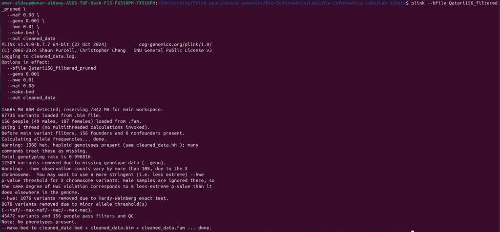

filter data

## Create ped and map files from cleaned data

```bash
plink --bfile cleaned_data --recode --out cleaned_data
```

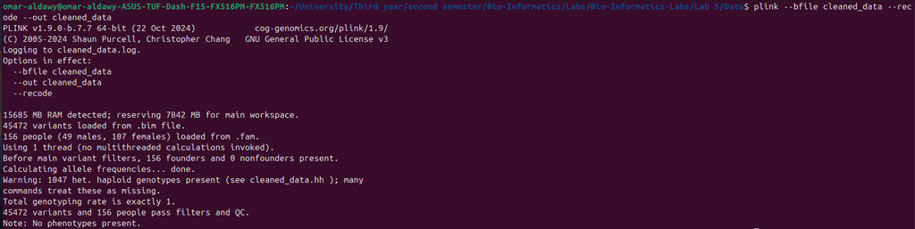

map and ped

## Calculate PCA (Eigen vectors and Eigen values)

```bash
plink --bfile cleaned_data \
  --pca \
  --out cleaned_data_pca
```

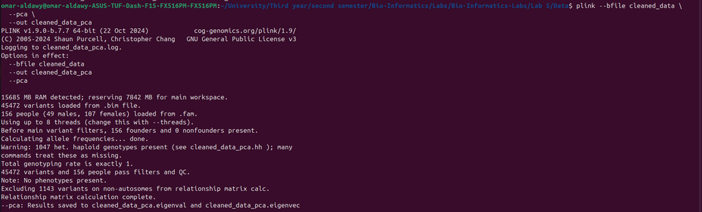

PCA

# Part 1: Identify SNPs associated with Population Structure

## Task 1.1: Identify SNPs associated with genomic PCs using Linear Regression Analysis

### Encode SNPs using additive approach

```bash
plink --bfile cleaned_data --recode A --out recoded_data
```

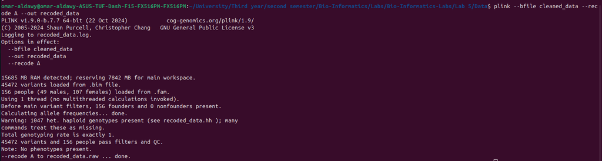

Additive Encoding

### Load required libraries

```r
install_and_load <- function(pkg) {
  if (!requireNamespace(pkg, quietly = TRUE)) {
    install.packages(pkg)
  }
  library(pkg, character.only = TRUE)
}

install_and_load("tidyverse")
install_and_load("scatterplot3d")
install_and_load("caret")
install_and_load("qqman")
```

### Read raw file and select the SNPs’ columns

```r
# Read the .raw file
geno <- read.table("Data/recoded_data.raw", header = TRUE, sep = "")

# Isolate only the SNP columns (after the first 6 columns)
snp_data <- geno %>% select(-(1:6))
```

### Read PCA components and select the top 3 components

```r
# Read the eigenvectors (PCs)
pcs <- read.table("Data/cleaned_data_pca.eigenvec", header = FALSE, sep = "")

# Assign column names
colnames(pcs) <- c("FID", "IID", paste0("PC", 1:20))  # If PLINK gives 20 PCs

# Join PCs with SNP data using individual IDs
merged_data <- cbind(pcs[, 3:5], snp_data)  # PC1, PC2, PC3 + SNPs
```

### Run 3 linear regression sets, each set is composed of one PC as a dependent variable against all SNPs while correcting the model for the other two PCs.

```r
results_pc1_stats <- lapply(snp_data, function(snp) {
  tryCatch({
    coefs <- summary(lm(PC1 ~ snp + PC2 + PC3, data = pcs[, 3:5]))$coefficients
    c(Beta = coefs[2, "Estimate"],
      SE = coefs[2, "Std. Error"],
      P_Value = coefs[2, "Pr(>|t|)"])
  }, error = function(e) c(Beta = NA, SE = NA, P_Value = NA))
})

# Convert list to data frame
results_pc1_df <- as.data.frame(do.call(rbind, results_pc1_stats))
results_pc1_df$SNP <- names(results_pc1_stats)

# Reorder columns
results_pc1_df <- results_pc1_df[, c("SNP", "Beta", "SE", "P_Value")]
```

```r
results_pc2_stats <- lapply(snp_data, function(snp) {
  tryCatch({
    coefs <- summary(lm(PC2 ~ snp + PC1 + PC3, data = pcs[, 3:5]))$coefficients
    c(Beta = coefs[2, "Estimate"],
      SE = coefs[2, "Std. Error"],
      P_Value = coefs[2, "Pr(>|t|)"])
  }, error = function(e) c(Beta = NA, SE = NA, P_Value = NA))
})

results_pc2_df <- as.data.frame(do.call(rbind, results_pc2_stats))
results_pc2_df$SNP <- names(results_pc2_stats)
results_pc2_df <- results_pc2_df[, c("SNP", "Beta", "SE", "P_Value")]
```

```r
results_pc3_stats <- lapply(snp_data, function(snp) {
  tryCatch({
    coefs <- summary(lm(PC3 ~ snp + PC1 + PC2, data = pcs[, 3:5]))$coefficients
    c(Beta = coefs[2, "Estimate"],
      SE = coefs[2, "Std. Error"],
      P_Value = coefs[2, "Pr(>|t|)"])
  }, error = function(e) c(Beta = NA, SE = NA, P_Value = NA))
})

results_pc3_df <- as.data.frame(do.call(rbind, results_pc3_stats))
results_pc3_df$SNP <- names(results_pc3_stats)
results_pc3_df <- results_pc3_df[, c("SNP", "Beta", "SE", "P_Value")]
```

### Calculate Bonferroni-threshold and determine the significant SNPs

```r
bonf_threshold <- 0.05 / ncol(snp_data)

# Significant SNPs
sig_snps_pc1 <- results_pc1_df %>% filter(P_Value < bonf_threshold)
sig_snps_pc2 <- results_pc2_df %>% filter(P_Value < bonf_threshold)
sig_snps_pc3 <- results_pc3_df %>% filter(P_Value < bonf_threshold)
```

```r
cat("Bonferroni threshold =", bonf_threshold, "\n")
```

```
## Bonferroni threshold = 1.099578e-06
```

```r
print(sig_snps_pc1)
```

```
##                       SNP        Beta          SE      P_Value
## rs2840528_G   rs2840528_G  0.04994067 0.008196754 8.725736e-09
## rs4292923_C   rs4292923_C  0.10635554 0.013883082 2.015266e-12
## rs11260666_A rs11260666_A  0.11453846 0.013908285 7.631473e-14
## rs6577427_C   rs6577427_C  0.09317253 0.012245854 2.702390e-12
## rs10495758_C rs10495758_C  0.07642655 0.010203836 5.237015e-12
## rs1341306_A   rs1341306_A  0.10216991 0.011009502 1.620866e-16
## rs4912105_C   rs4912105_C  0.09410705 0.013489052 8.721246e-11
## rs213037_A     rs213037_A  0.09490631 0.010291362 2.296592e-16
## rs2473317_G   rs2473317_G  0.05521725 0.010581417 5.830156e-07
## rs4514282_C   rs4514282_C  0.10922881 0.011393975 2.567321e-17
## rs4659378_G   rs4659378_G  0.05448211 0.008429088 1.314465e-09
## rs578800_A     rs578800_A  0.07684477 0.013708845 9.519002e-08
## rs12033154_A rs12033154_A  0.06922845 0.011419395 1.016144e-08
## rs10493049_G rs10493049_G  0.06870228 0.011603553 2.054604e-08
## rs4970614_T   rs4970614_T  0.06027787 0.011664598 7.348388e-07
## rs2492791_G   rs2492791_G  0.08919452 0.016269314 1.708555e-07
## rs320050_C     rs320050_C  0.07499209 0.010751426 8.790445e-11
## rs2494884_T   rs2494884_T  0.05996237 0.010098462 1.889209e-08
## rs884586_C     rs884586_C  0.08946004 0.014426933 5.055560e-09
## rs6676020_C   rs6676020_C  0.05854612 0.010088884 3.663747e-08
## rs834347_T     rs834347_T  0.06828249 0.009258033 9.881933e-12
## rs305580_G     rs305580_G  0.05910513 0.010280162 4.756329e-08
## rs635154_T     rs635154_T  0.05402099 0.008295005 1.019636e-09
## rs10889553_A rs10889553_A  0.09570667 0.013413412 3.694024e-11
## rs1158573_A   rs1158573_A  0.05733075 0.008899084 1.467529e-09
## rs1358041_C   rs1358041_C -0.04753138 0.008456552 8.852239e-08
## rs10449706_G rs10449706_G  0.08820171 0.015327900 4.644715e-08
## rs9324189_G   rs9324189_G  0.04633934 0.008669873 3.252855e-07
## rs315542_A     rs315542_A  0.06025040 0.011523171 5.561370e-07
## rs3003703_C   rs3003703_C  0.12109438 0.011685144 2.275372e-19
## rs17130950_T rs17130950_T  0.07822025 0.013919457 8.901884e-08
## rs12134748_A rs12134748_A -0.04915393 0.008145925 1.169926e-08
## rs10157512_G rs10157512_G  0.05817704 0.010332371 8.441835e-08
## rs514341_T     rs514341_T  0.07848954 0.010837966 2.059399e-11
## rs2820095_T   rs2820095_T  0.06418260 0.010844818 2.080384e-08
## rs6692745_G   rs6692745_G  0.04992639 0.008923879 1.002302e-07
## rs6665259_A   rs6665259_A  0.07998644 0.012899412 5.058726e-09
## rs10801944_G rs10801944_G  0.05190252 0.009608278 2.494107e-07
## rs6674970_G   rs6674970_G  0.05489098 0.008871843 5.421869e-09
```

[output cut: 1079 more lines]

```
## rs6528444_A   rs6528444_A  0.04588745 0.008802028 5.966154e-07
## rs5974804_C   rs5974804_C  0.04015014 0.007368371 1.999580e-07
## rs5909010_T   rs5909010_T  0.09644518 0.010669428 6.822567e-16
## rs5954038_C   rs5954038_C  0.05820387 0.007677074 3.142860e-12
## rs5954072_T   rs5954072_T  0.08670222 0.013678416 2.504364e-09
## rs6636441_C   rs6636441_C  0.04380581 0.007186619 8.606873e-09
## rs971662_A     rs971662_A  0.04149235 0.007539240 1.546134e-07
## rs5954844_A   rs5954844_A  0.07761133 0.010573776 1.202177e-11
## rs5908525_A   rs5908525_A  0.07000119 0.011560746 1.053863e-08
## rs5945492_C   rs5945492_C  0.04208736 0.007728145 2.027975e-07
## rs5920606_A   rs5920606_A -0.03905591 0.007412709 4.624884e-07
## rs1740317_G   rs1740317_G  0.06439695 0.010175096 2.632606e-09
## rs5920320_T   rs5920320_T  0.06187367 0.008512177 1.778265e-11
## rs5969969_C   rs5969969_C  0.04789097 0.008350828 5.104509e-08
## rs6526129_A   rs6526129_A  0.05174069 0.009421896 1.636237e-07
```

```r
print(sig_snps_pc2)
```

```
##                       SNP        Beta          SE      P_Value
## rs7530095_T   rs7530095_T -0.04718314 0.008914476 4.138699e-07
## rs4656856_T   rs4656856_T  0.05059284 0.009515057 3.699414e-07
## rs4655445_G   rs4655445_G  0.04632018 0.008776380 4.436141e-07
## rs3101468_A   rs3101468_A  0.07059358 0.012296911 4.960976e-08
## rs9326164_G   rs9326164_G  0.07864562 0.015391217 9.549412e-07
## rs4337447_C   rs4337447_C -0.06972337 0.013706980 1.059605e-06
## rs4954599_A   rs4954599_A  0.04551038 0.008093808 8.759183e-08
## rs867005_T     rs867005_T  0.04638286 0.008693618 3.401024e-07
## rs6749365_A   rs6749365_A -0.04537326 0.008812440 8.004105e-07
## rs2922309_G   rs2922309_G  0.06841554 0.012586667 2.129792e-07
## rs4854102_T   rs4854102_T  0.03983115 0.007748418 8.308146e-07
## rs4894705_T   rs4894705_T  0.04910319 0.008516508 4.395937e-08
## rs28711160_G rs28711160_G  0.04954780 0.008278973 1.496379e-08
## rs7355960_T   rs7355960_T -0.10160636 0.017983554 7.691093e-08
## rs2111278_C   rs2111278_C  0.06451385 0.012151277 3.837368e-07
## rs2711158_G   rs2711158_G -0.05899593 0.010263347 4.784602e-08
## rs2642849_G   rs2642849_G  0.04986479 0.009631653 7.034651e-07
## rs17754933_G rs17754933_G  0.07933893 0.014037293 7.615658e-08
## rs2880416_G   rs2880416_G  0.07421542 0.012296584 1.162493e-08
## rs749169_C     rs749169_C -0.08549943 0.013944859 7.189041e-09
## rs2445074_A   rs2445074_A  0.04884724 0.009497185 8.203884e-07
## rs9350410_G   rs9350410_G -0.04196033 0.008194167 9.087111e-07
## rs259396_C     rs259396_C  0.05300145 0.010337043 8.820775e-07
## rs10499504_G rs10499504_G  0.07753682 0.014826619 5.537518e-07
## rs2241056_T   rs2241056_T  0.08149100 0.014079356 3.942995e-08
## rs10261664_G rs10261664_G  0.06408976 0.011622792 1.470297e-07
## rs6965479_A   rs6965479_A  0.05739015 0.010991627 5.752271e-07
## rs7835212_C   rs7835212_C  0.05089596 0.008602693 2.100940e-08
## rs2410516_T   rs2410516_T -0.04485630 0.008818629 1.060399e-06
## rs7821631_T   rs7821631_T  0.07801595 0.015031128 6.626610e-07
## rs2599675_T   rs2599675_T -0.04414393 0.008173891 2.508765e-07
## rs10122575_C rs10122575_C  0.04519746 0.008437219 3.075721e-07
## rs340900_C     rs340900_C  0.04367409 0.008493300 8.247023e-07
## rs9299046_G   rs9299046_G  0.06130128 0.011297227 2.225120e-07
## rs10960942_G rs10960942_G  0.04867157 0.009456574 8.074278e-07
## rs10961166_C rs10961166_C -0.04844963 0.008921905 2.181821e-07
## rs10905087_A rs10905087_A -0.05275299 0.010105193 5.775397e-07
## rs3895938_A   rs3895938_A  0.05510645 0.009645422 5.668916e-08
## rs1326644_A   rs1326644_A -0.04846500 0.008069194 1.345240e-08
```

[output cut: 25 more lines]

```
## rs9894837_G   rs9894837_G -0.05155044 0.009916456 6.383795e-07
## rs2447095_A   rs2447095_A -0.05421104 0.008898767 8.759342e-09
## rs6502937_T   rs6502937_T  0.04539183 0.008027855 7.532626e-08
## rs7501602_T   rs7501602_T -0.05670980 0.009621571 2.344699e-08
## rs933577_T     rs933577_T  0.06990778 0.012919484 2.389238e-07
## rs2526354_C   rs2526354_C  0.06471686 0.011932048 2.250715e-07
## rs9895541_A   rs9895541_A -0.08704013 0.015312614 6.521814e-08
## rs4911540_T   rs4911540_T  0.06466941 0.012126381 3.437899e-07
## rs6073285_C   rs6073285_C  0.07618534 0.014418026 4.310896e-07
## rs2281202_T   rs2281202_T  0.07737222 0.015058355 8.398758e-07
## rs6024378_T   rs6024378_T  0.05515709 0.010368071 3.652339e-07
## rs5998067_G   rs5998067_G  0.06950017 0.012641097 1.587369e-07
## rs727048_T     rs727048_T  0.05413148 0.010627086 1.026617e-06
## rs5770498_T   rs5770498_T -0.04376663 0.007920554 1.391933e-07
## rs6588874_G   rs6588874_G  0.06861568 0.012857675 3.380911e-07
```

```r
print(sig_snps_pc3)
```

```
##                       SNP        Beta          SE      P_Value
## rs12078697_C rs12078697_C -0.04657890 0.008446644 1.467925e-07
## rs6679275_A   rs6679275_A -0.04691387 0.009063685 7.071678e-07
## rs4684859_A   rs4684859_A  0.05284539 0.008509981 4.832211e-09
## rs17609498_T rs17609498_T  0.06919924 0.013605526 1.062434e-06
## rs2204732_C   rs2204732_C -0.04799006 0.008195540 2.831991e-08
## rs7793347_T   rs7793347_T  0.06437681 0.011445520 8.685355e-08
## rs11820583_C rs11820583_C  0.05588871 0.009271381 1.206009e-08
## rs7104248_G   rs7104248_G -0.04367106 0.008196759 3.520309e-07
## rs11050714_A rs11050714_A  0.04741429 0.008908471 3.610561e-07
## rs10850824_G rs10850824_G  0.05709974 0.008021524 4.048356e-11
## rs17661962_C rs17661962_C  0.05121937 0.009876104 6.751672e-07
## rs16963743_A rs16963743_A  0.09453990 0.014670443 1.452997e-09
```

## Task 2.2: Identify SNPs that associate with the population subgroups (clusters) using logistic regression

### Run the k-means clustering algorithm using the first 3 PCs and plot the 3D scatterplot.

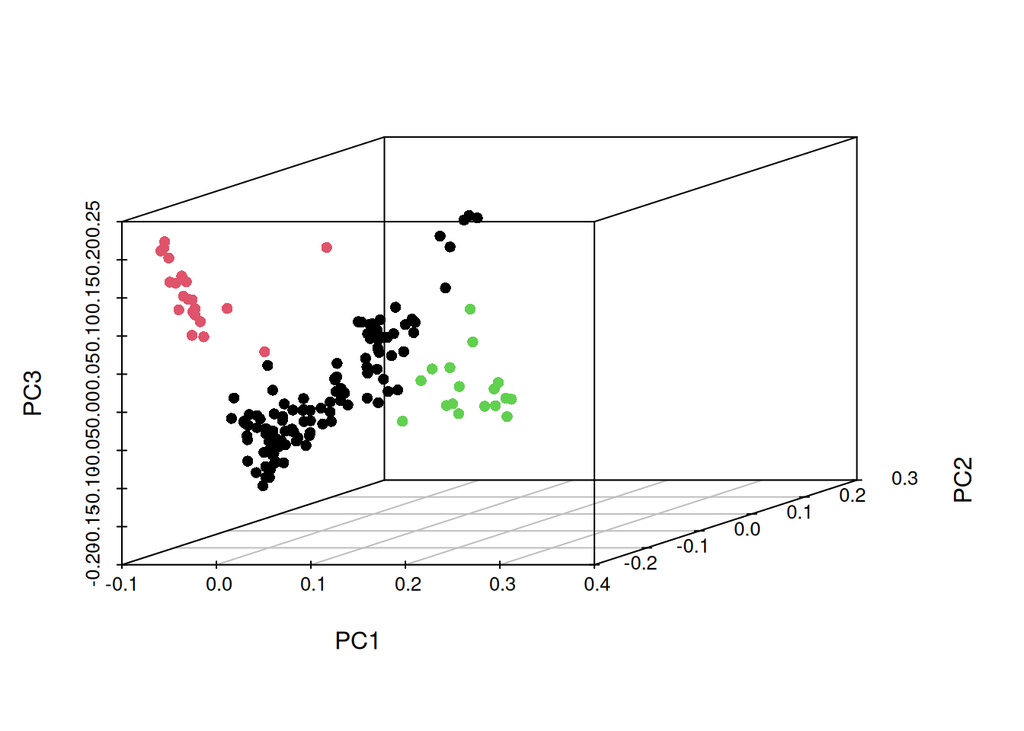

```r
# Set seed and cluster
set.seed(42)
kmeans_res <- kmeans(merged_data[, c("PC1", "PC2", "PC3")],
                     centers = 3,
                     nstart = 25,
                     iter.max = 1000)

# 3D plot
scatterplot3d(merged_data$PC1,
              merged_data$PC2,
              merged_data$PC3,
              color = kmeans_res$cluster,
              xlab = "PC1",
              ylab = "PC2",
              zlab = "PC3",
              pch = 16)
```

### Perform one-hot encoding for the cluster labels obtained from the k means.

```r
# One-hot encode cluster labels
merged_data$cluster <- as.factor(kmeans_res$cluster)
dummies <- dummyVars(~ cluster, data = merged_data)
cluster_encoded <- predict(dummies, newdata = merged_data)
merged_cluster <- cbind(merged_data, cluster_encoded)
```

### Perform logistic regression as each set is composed of cluster encoding against all SNPs.

```r
# Logistic regression for cluster 1 (cluster.1 encoded as dependent variable)
results_cluster1_stats <- lapply(snp_data, function(snp) {
  tryCatch({
    coefs <- summary(glm(cluster_encoded[, 1] ~ snp, family = binomial))$coefficients
    c(Beta = coefs[2, "Estimate"],
      SE = coefs[2, "Std. Error"],
      P_Value = coefs[2, "Pr(>|z|)"])
  }, error = function(e) c(Beta = NA, SE = NA, P_Value = NA))
})

results_cluster1_df <- as.data.frame(do.call(rbind, results_cluster1_stats))
results_cluster1_df$SNP <- names(results_cluster1_stats)
results_cluster1_df <- results_cluster1_df[, c("SNP", "Beta", "SE", "P_Value")]
```

```r
# Logistic regression for cluster 2 (cluster.2 encoded as dependent variable)
results_cluster2_stats <- lapply(snp_data, function(snp) {
  tryCatch({
    coefs <- summary(glm(cluster_encoded[, 2] ~ snp, family = binomial))$coefficients
    c(Beta = coefs[2, "Estimate"],
      SE = coefs[2, "Std. Error"],
      P_Value = coefs[2, "Pr(>|z|)"])
  }, error = function(e) c(Beta = NA, SE = NA, P_Value = NA))
})

results_cluster2_df <- as.data.frame(do.call(rbind, results_cluster2_stats))
results_cluster2_df$SNP <- names(results_cluster2_stats)
results_cluster2_df <- results_cluster2_df[, c("SNP", "Beta", "SE", "P_Value")]
```

```r
# Logistic regression for cluster 3 (cluster.3 encoded as dependent variable)
results_cluster3_stats <- lapply(snp_data, function(snp) {
  tryCatch({
    coefs <- summary(glm(cluster_encoded[, 3] ~ snp, family = binomial))$coefficients
    c(Beta = coefs[2, "Estimate"],
      SE = coefs[2, "Std. Error"],
      P_Value = coefs[2, "Pr(>|z|)"])
  }, error = function(e) c(Beta = NA, SE = NA, P_Value = NA))
})

results_cluster3_df <- as.data.frame(do.call(rbind, results_cluster3_stats))
results_cluster3_df$SNP <- names(results_cluster3_stats)
results_cluster3_df <- results_cluster3_df[, c("SNP", "Beta", "SE", "P_Value")]
```

### Identify significant SNPs that are associated with each of the 3 clusters using a Bonferroni threshold

```r
sig_snps_cluster1 <- results_cluster1_df %>% filter(P_Value < bonf_threshold)
sig_snps_cluster2 <- results_cluster2_df %>% filter(P_Value < bonf_threshold)
sig_snps_cluster3 <- results_cluster3_df %>% filter(P_Value < bonf_threshold)
```

```r
print(sig_snps_cluster1)
```

```
##                     SNP      Beta        SE      P_Value
## rs4337447_C rs4337447_C -2.230629 0.4203683 1.118315e-07
## rs9784244_C rs9784244_C -2.052706 0.4208190 1.072301e-06
## rs6597149_T rs6597149_T -1.682329 0.3305979 3.604412e-07
## rs1561081_A rs1561081_A -1.825045 0.3706886 8.505663e-07
## rs286911_T   rs286911_T -1.598594 0.3277967 1.078281e-06
## rs6562034_T rs6562034_T -1.942455 0.3899805 6.328769e-07
## rs222670_C   rs222670_C -2.284550 0.4115623 2.841681e-08
## rs936873_C   rs936873_C -2.160374 0.4147789 1.903781e-07
## rs9895541_A rs9895541_A -2.671420 0.5252317 3.653592e-07
## rs9956302_C rs9956302_C -1.890742 0.3860664 9.708730e-07
## rs455052_T   rs455052_T -2.106841 0.4244375 6.911217e-07
```

```r
print(sig_snps_cluster2)
```

```
##                       SNP     Beta        SE      P_Value
## rs12126278_T rs12126278_T 2.224858 0.4358491 3.314027e-07
## rs10000959_C rs10000959_C 2.394240 0.4895808 1.006376e-06
## rs17197376_A rs17197376_A 2.674764 0.5271533 3.895837e-07
## rs10850824_G rs10850824_G 2.567891 0.5038685 3.462628e-07
## rs2447095_A   rs2447095_A 2.320307 0.4756415 1.070212e-06
## rs16963743_A rs16963743_A 2.507515 0.5101845 8.881912e-07
```

```r
print(sig_snps_cluster3)
```

```
##                       SNP     Beta        SE      P_Value
## rs4292923_C   rs4292923_C 2.935397 0.5929865 7.413990e-07
## rs1341306_A   rs1341306_A 3.268261 0.6624549 8.074430e-07
## rs4514282_C   rs4514282_C 3.084115 0.6107341 4.421591e-07
## rs884586_C     rs884586_C 3.101498 0.6228209 6.366351e-07
## rs3003703_C   rs3003703_C 4.089437 0.8020323 3.417357e-07
## rs12618771_C rs12618771_C 2.885550 0.5857220 8.372267e-07
## rs12613530_T rs12613530_T 3.934509 0.7941867 7.265262e-07
## rs7636104_C   rs7636104_C 3.087201 0.6032723 3.097341e-07
## rs6766988_A   rs6766988_A 2.205972 0.4504623 9.724674e-07
## rs1381083_C   rs1381083_C 3.811778 0.6997202 5.106143e-08
## rs4349736_A   rs4349736_A 2.615866 0.5334929 9.424926e-07
## rs2569885_T   rs2569885_T 2.784532 0.5694726 1.010059e-06
## rs2560768_T   rs2560768_T 2.863927 0.5793256 7.671129e-07
## rs9321616_C   rs9321616_C 3.412036 0.6796083 5.151240e-07
## rs10272163_G rs10272163_G 2.386399 0.4824218 7.547954e-07
## rs6945984_C   rs6945984_C 2.633734 0.5261651 5.570934e-07
## rs6997614_G   rs6997614_G 2.895950 0.5838477 7.045254e-07
## rs12267286_C rs12267286_C 3.109034 0.6050063 2.764313e-07
## rs7100515_C   rs7100515_C 2.940312 0.5889476 5.960733e-07
## rs10788091_T rs10788091_T 3.130277 0.6075738 2.575958e-07
## rs4938639_G   rs4938639_G 2.483142 0.4908060 4.207641e-07
## rs1944605_A   rs1944605_A 3.008691 0.5978435 4.839398e-07
## rs2643626_G   rs2643626_G 3.101498 0.6228209 6.366351e-07
## rs11148886_C rs11148886_C 3.194738 0.6476954 8.119593e-07
## rs7148755_C   rs7148755_C 2.855381 0.5730049 6.255085e-07
## rs728244_A     rs728244_A 3.376367 0.6801137 6.890836e-07
## rs8053877_T   rs8053877_T 2.515737 0.5085196 7.529712e-07
## rs8045281_T   rs8045281_T 3.150979 0.6110833 2.517677e-07
## rs7186136_C   rs7186136_C 3.254143 0.6307302 2.478400e-07
## rs9904395_G   rs9904395_G 3.285991 0.6326800 2.060833e-07
## rs4798212_T   rs4798212_T 3.424385 0.6783819 4.467582e-07
## rs9967367_T   rs9967367_T 2.462477 0.5014668 9.082251e-07
## rs1304551_T   rs1304551_T 3.556072 0.6636572 8.401059e-08
## rs2965157_C   rs2965157_C 2.784532 0.5694726 1.010059e-06
## rs6095097_T   rs6095097_T 2.384336 0.4863886 9.480720e-07
## rs2847443_A   rs2847443_A 3.183546 0.6255380 3.594002e-07
## rs2824011_C   rs2824011_C 2.839101 0.5766307 8.496496e-07
## rs5943477_T   rs5943477_T 2.211207 0.4455963 6.964339e-07
## rs5909010_T   rs5909010_T 2.538619 0.4914584 2.398204e-07
```

## Task 2: Manhattan, Annotation, and Discussion

### Load map file of the cleaned data to use it for the plot

```r
map_data <- read.table("Data/cleaned_data.map", header = FALSE)
colnames(map_data) <- c("CHR", "SNP", "GD", "BP")
```

### Use the values we got before from the analysis

```r
results_linear_pc1_df <- data.frame(SNP = rownames(results_pc1_df),
                                P = results_pc1_df[,"P_Value"])

results_linear_pc2_df <- data.frame(SNP = rownames(results_pc2_df),
                                P = results_pc2_df[,"P_Value"])

results_linear_pc3_df <- data.frame(SNP = rownames(results_pc3_df),
                                P = results_pc3_df[,"P_Value"])


results_logistic_cluster1_df <- data.frame(SNP = rownames(results_cluster1_df),
                                        P = results_cluster1_df[,"P_Value"])

results_logistic_cluster2_df <- data.frame(SNP = rownames(results_cluster2_df),
                                        P = results_cluster2_df[,"P_Value"])

results_logistic_cluster3_df <- data.frame(SNP = rownames(results_cluster3_df),
                                        P = results_cluster3_df[,"P_Value"])
```

### Editing SNPs column as we need it to merge with the table from map file

```r
results_linear_pc1_df$SNP <- substr(results_linear_pc1_df$SNP, 1,
                                    nchar(results_linear_pc1_df$SNP) - 2)

results_linear_pc2_df$SNP <- substr(results_linear_pc2_df$SNP, 1,
                                    nchar(results_linear_pc2_df$SNP) - 2)

results_linear_pc3_df$SNP <- substr(results_linear_pc3_df$SNP, 1,
                                    nchar(results_linear_pc3_df$SNP) - 2)


results_logistic_cluster1_df$SNP <- substr(results_logistic_cluster1_df$SNP, 1,
                                    nchar(results_logistic_cluster1_df$SNP) - 2)

results_logistic_cluster2_df$SNP <- substr(results_logistic_cluster2_df$SNP, 1,
                                    nchar(results_logistic_cluster2_df$SNP) - 2)

results_logistic_cluster3_df$SNP <- substr(results_logistic_cluster3_df$SNP, 1,
                                    nchar(results_logistic_cluster3_df$SNP) - 2)
```

### Merging the two tables to make the data ready for plotting

```r
manhattan_data_pc1 <- merge(map_data, results_linear_pc1_df, by = "SNP")
manhattan_data_pc2 <- merge(map_data, results_linear_pc2_df, by = "SNP")
manhattan_data_pc3 <- merge(map_data, results_linear_pc3_df, by = "SNP")

manhattan_data_cluster1 <- merge(map_data, results_logistic_cluster1_df, by = "SNP")
manhattan_data_cluster2 <- merge(map_data, results_logistic_cluster2_df, by = "SNP")
manhattan_data_cluster3 <- merge(map_data, results_logistic_cluster3_df, by = "SNP")
```

### Function to plot Manhattan-Plot

```r
draw_manhattan_plot <- function(data, title) {
  #data <- data %>% filter(CHR < 23)
  manhattan(data,
            main = title,
            col = c("skyblue", "orange"),
            suggestiveline = FALSE,
            genomewideline = -log10(bonf_threshold))
}
```

### Drawing Manhattan-Plots for the p-values we got from each analysis we had made

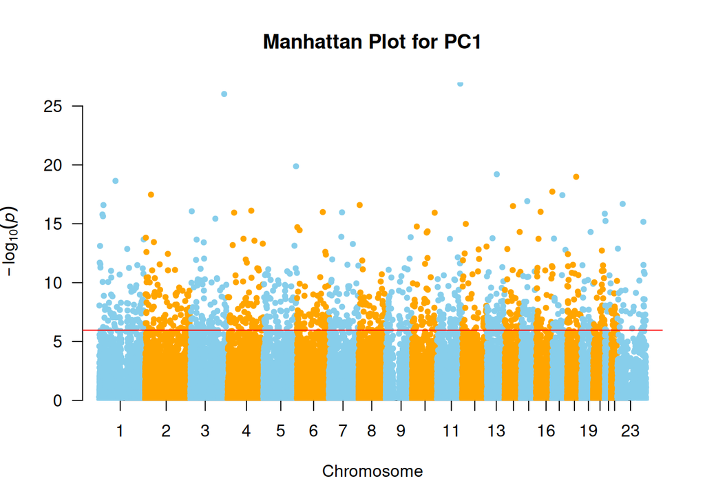

```r
draw_manhattan_plot(manhattan_data_pc1, "Manhattan Plot for PC1")
```

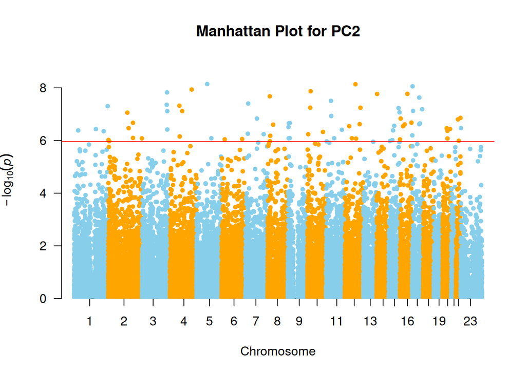

```r
draw_manhattan_plot(manhattan_data_pc2, "Manhattan Plot for PC2")
```

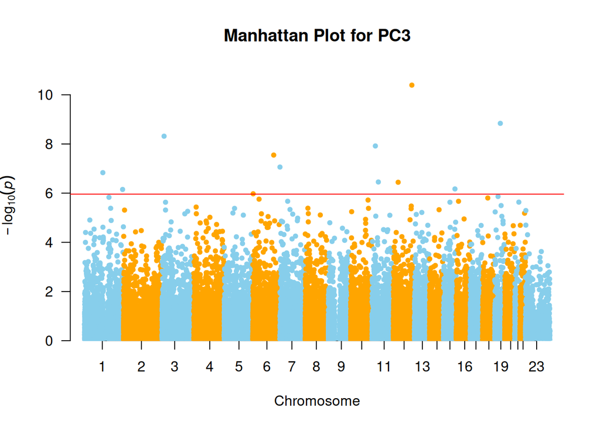

```r
draw_manhattan_plot(manhattan_data_pc3, "Manhattan Plot for PC3")
```

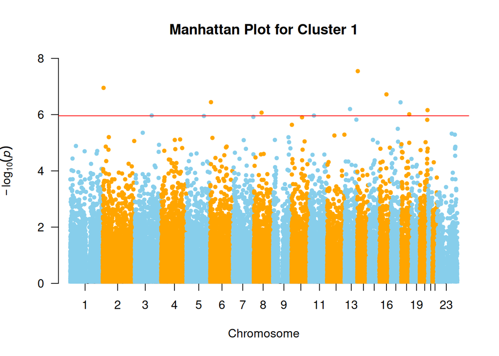

```r
draw_manhattan_plot(manhattan_data_cluster1, "Manhattan Plot for Cluster 1")
```

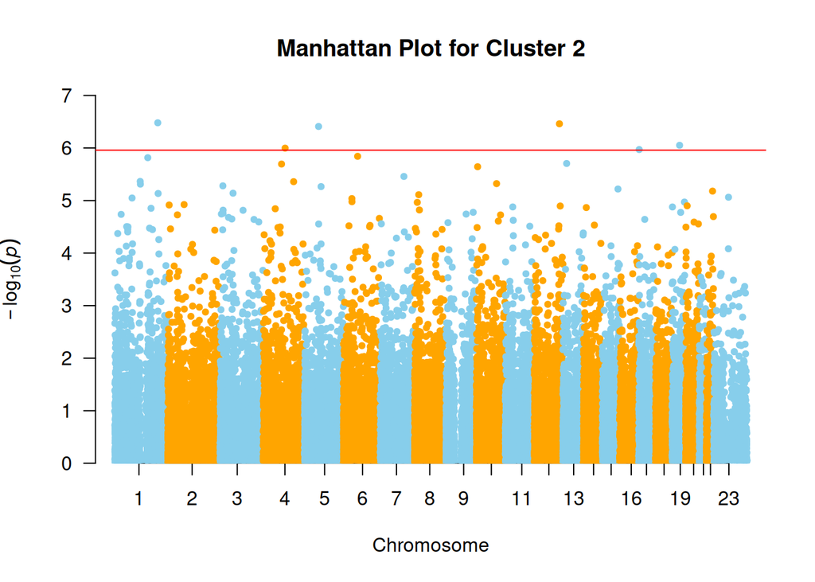

```r
draw_manhattan_plot(manhattan_data_cluster2, "Manhattan Plot for Cluster 2")
```

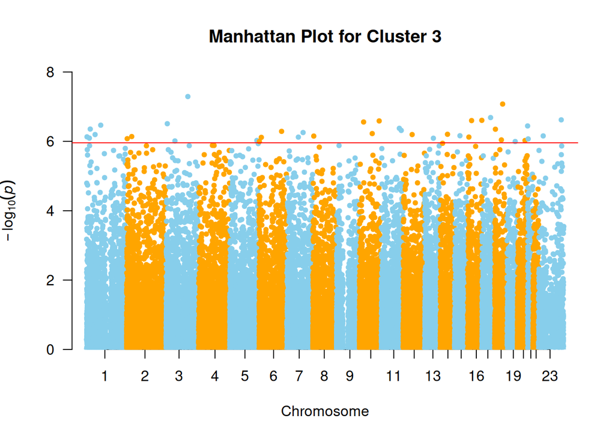

```r
draw_manhattan_plot(manhattan_data_cluster3, "Manhattan Plot for Cluster 3")
```

### Get the top 10 significant SNPs

```r
top10 <- results_pc1_df[order(results_pc1_df[,"P_Value"]), ][1:10, ]
top10 <- data.frame(top10)
top10$SNP <- substr(top10$SNP, 1, nchar(top10$SNP) - 2)
# Merge the positional information
annotated_top10 <- merge(top10, map_data, by.x = "SNP", by.y = "SNP")
annotated_top10 <- annotated_top10[order(annotated_top10$P_Value), ]
```

### Use dbSNP from NCBI website to check the information on the 10 most significant SNPs from the linear regression and PC1

```r
gene_names <- c("MSANTD2", "MFN1", "Introne", "DACH1", "DCC", "Introne",
                "Introne", "CAPN14", "MSI2", "LOC124903496")
freq <- c(
"C=0.255752/4958 (ALFA)
C=0.171667/103 (NorthernSweden)
C=0.175926/38 (Qatari)
C=0.200401/200 (GoNL)
C=0.200647/744 (TWINSUK)
C=0.201349/776 (ALSPAC)
C=0.202009/905 (Estonian)
C=0.202812/163393 (GnomAD_exomes)
C=0.208333/45 (Vietnamese)
C=0.275/11 (GENOME_DK)
C=0.277317/2005 (Korea4K)
C=0.282253/827 (KOREAN)
C=0.290393/532 (Korea1K)
C=0.327309/48731 (GnomAD_genomes)
C=0.334913/25935 (TOMMO)
C=0.345248/1729 (1000Genomes)
C=0.345313/91401 (TOPMED)
C=0.352124/2255 (1000Genomes_30X)
G=0.355856/79 (SGDP_PRJ)
C=0.40625/767 (HapMap)
G=0.416667/5 (Siberian)",

"T=0.019987/5600 (ALFA)
T=0.001563/7 (Estonian)
T=0.002004/2 (GoNL)
T=0.002967/11 (TWINSUK)
T=0.003633/14 (ALSPAC)
T=0.017572/11 (Chileans)
T=0.115741/25 (Qatari)
T=0.128333/19125 (GnomAD_genomes)
T=0.142469/37710 (TOPMED)
T=0.14976/750 (1000Genomes)
T=0.156777/1004 (1000Genomes_30X)
T=0.206066/16217 (PAGE_STUDY)
C=0.28125/18 (SGDP_PRJ)
T=0.317708/366 (HapMap)",

"A=0.066912/3077 (ALFA)
A=0./0 (PRJEB36033)
A=0.000446/2 (Estonian)
A=0.001002/1 (GoNL)
A=0.00204/158 (TOMMO)
A=0.002427/9 (TWINSUK)
A=0.003114/12 (ALSPAC)
A=0.004147/30 (Korea4K)
A=0.005818/17 (KOREAN)
A=0.00655/12 (Korea1K)
A=0.023962/15 (Chileans)
A=0.115741/25 (Qatari)
A=0.132941/19830 (GnomAD_genomes)
A=0.149361/748 (1000Genomes)
A=0.150652/39876 (TOPMED)
A=0.158807/1017 (1000Genomes_30X)
A=0.247235/447 (HapMap)
G=0.297297/22 (SGDP_PRJ)",

"C=0.156855/2963 (ALFA)
C=0.024107/108 (Estonian)
C=0.028333/17 (NorthernSweden)
C=0.039105/145 (TWINSUK)
C=0.03944/152 (ALSPAC)
C=0.194444/42 (Qatari)
C=0.25609/38120 (GnomAD_genomes)
C=0.258646/20013 (TOMMO)
C=0.262637/769 (KOREAN)
C=0.265833/1914 (Korea4K)
C=0.273585/58 (Vietnamese)
C=0.286868/75931 (TOPMED)
C=0.322684/1616 (1000Genomes)
C=0.335728/2150 (1000Genomes_30X)
G=0.347368/66 (SGDP_PRJ)
C=0.411111/777 (HapMap)
G=0.5/9 (Siberian)",

"T=0.061196/1156 (ALFA)
T=0./0 (GENOME_DK)
C=0./0 (KOREAN)
T=0./0 (Korea1K)
T=0./0 (Korea4K)
T=0./0 (NorthernSweden)
T=0./0 (Siberian)
T=0./0 (Vietnamese)
T=0.000039/3 (TOMMO)
T=0.000778/3 (ALSPAC)
T=0.001002/1 (GoNL)
T=0.001618/6 (TWINSUK)
T=0.027778/15 (SGDP_PRJ)
A=0.046816/25 (MGP)
T=0.097222/21 (Qatari)
T=0.10416/15525 (GnomAD_genomes)
T=0.110423/553 (1000Genomes)
T=0.112586/721 (1000Genomes_30X)
T=0.118187/31283 (TOPMED)
T=0.272727/348 (HapMap)",

"C=0.091795/1734 (ALFA)
C=0.008091/30 (TWINSUK)
C=0.010638/41 (ALSPAC)
C=0.011079/858 (TOMMO)
C=0.011667/7 (NorthernSweden)
C=0.014028/14 (GoNL)
C=0.015402/69 (Estonian)
C=0.017454/51 (KOREAN)
C=0.019635/142 (Korea4K)
C=0.019651/36 (Korea1K)
C=0.117925/25 (Vietnamese)
C=0.134259/29 (Qatari)
C=0.153379/22855 (GnomAD_genomes)
C=0.166674/44117 (TOPMED)
C=0.167732/840 (1000Genomes)
C=0.173641/1112 (1000Genomes_30X)
C=0.207632/370 (HapMap)
G=0.358696/33 (SGDP_PRJ)
G=0.5/1 (Siberian)",

"C=0.158421/33521 (ALFA)
C=0.000684/2 (KOREAN)
C=0.106481/23 (Qatari)
C=0.108696/10 (PRJEB36033)
C=0.112764/235 (HGDP_Stanford)
C=0.135783/85 (Chileans)
C=0.156473/701 (Estonian)
C=0.160093/617 (ALSPAC)
C=0.161003/597 (TWINSUK)
C=0.16893/846 (1000Genomes)
C=0.173333/104 (NorthernSweden)
C=0.175/7 (GENOME_DK)
C=0.175828/1126 (1000Genomes_30X)
C=0.178357/178 (GoNL)
C=0.203465/30355 (GnomAD_genomes)
C=0.212369/56212 (TOPMED)
C=0.212963/368 (HapMap)
T=0.433962/46 (SGDP_PRJ)
T=0.5/5 (Siberian)",

"T=0.058562/1846 (ALFA)
T=0.010491/47 (Estonian)
T=0.014028/14 (GoNL)
T=0.01453/56 (ALSPAC)
T=0.015642/58 (TWINSUK)
T=0.025/1 (GENOME_DK)
T=0.031667/19 (NorthernSweden)
T=0.036741/23 (Chileans)
T=0.119623/17820 (GnomAD_genomes)
T=0.125/27 (Qatari)
T=0.131641/34844 (TOPMED)
T=0.180911/906 (1000Genomes)
T=0.2004/15515 (TOMMO)
T=0.203042/15979 (PAGE_STUDY)
T=0.203057/372 (Korea1K)
T=0.206167/1491 (Korea4K)
T=0.219113/642 (KOREAN)
T=0.222222/48 (Vietnamese)
T=0.2463/466 (HapMap)
C=0.333333/2 (Siberian)
C=0.353448/41 (SGDP_PRJ)",

"G=0.060874/9517 (ALFA)
G=0.014927/1156 (TOMMO)
G=0.020534/60 (KOREAN)
G=0.025/1 (GENOME_DK)
G=0.026201/48 (Korea1K)
G=0.029721/215 (Korea4K)
G=0.03125/2 (PRJEB36033)
G=0.031667/19 (NorthernSweden)
G=0.037074/37 (GoNL)
G=0.039914/148 (TWINSUK)
G=0.040477/156 (ALSPAC)
G=0.047923/30 (Chileans)
G=0.070089/314 (Estonian)
G=0.087963/19 (Qatari)
G=0.098369/205 (HGDP_Stanford)
G=0.146694/21834 (GnomAD_genomes)
G=0.153754/770 (1000Genomes)
G=0.157402/1008 (1000Genomes_30X)
G=0.15896/42075 (TOPMED)
G=0.222516/421 (HapMap)
A=0.319149/30 (SGDP_PRJ)
A=0.5/5 (Siberian)",

"A=0.273214/9704 (ALFA)
A=0.120982/542 (Estonian)
A=0.125/5 (GENOME_DK)
A=0.129393/81 (Chileans)
A=0.147295/147 (GoNL)
A=0.151012/582 (ALSPAC)
A=0.152373/565 (TWINSUK)
A=0.196667/118 (NorthernSweden)
A=0.242043/1749 (Korea4K)
A=0.244541/448 (Korea1K)
A=0.248802/727 (KOREAN)
A=0.277778/60 (Qatari)
A=0.278136/21540 (TOMMO)
A=0.296296/64 (Vietnamese)
G=0.302419/75 (SGDP_PRJ)
A=0.338911/50497 (GnomAD_genomes)
A=0.354978/93959 (TOPMED)
A=0.404553/2026 (1000Genomes)
A=0.410369/2628 (1000Genomes_30X)
G=0.444444/8 (Siberian)
A=0.457266/35985 (PAGE_STUDY)
A=0.487831/922 (HapMap)")

max_freq <- c(0.416667, 0.317708, 0.297297, 0.5, 0.272727, 0.5, 0.5,
              0.353448, 0.5, 0.120982)
min_freq <- c(0.171667, 0.001563, 0., 0.024107,  0., 0.008091, 0.000684,
              0.010491, 0.014927, 0.487831)
```

### Finally our final table

```r
annotated_top10$Genes <- gene_names
annotated_top10$Freq <- freq
annotated_top10$Max_Freq <- max_freq
annotated_top10$Min_Freq <- min_freq

print(annotated_top10)
```

```
##           SNP       Beta          SE      P_Value CHR        GD        BP
## 1  rs10466604 0.10545991 0.007847282 1.241129e-27  11 124.15914 124159136
## 9   rs7355960 0.13388731 0.010212914 9.510475e-27   3 180.56674 180566740
## 6   rs6870937 0.11655557 0.010765138 1.313383e-20   5 175.09091 175090907
## 2  rs11148886 0.08428415 0.007970686 6.227159e-20  13  71.17852  71178521
## 4   rs1304551 0.12246555 0.011670046 1.019484e-19  18  48.56647  48566472
## 5   rs3003703 0.12109438 0.011685144 2.275372e-19   1  88.14932  88149315
## 7   rs7186136 0.12037338 0.012015210 1.869684e-18  16  87.65024  87650240
## 3  rs12613530 0.11991260 0.012084308 3.341921e-18   2  31.30746  31307461
## 10  rs9904395 0.11427182 0.011535211 3.698028e-18  17  52.79027  52790274
## 8    rs728244 0.07741564 0.007970992 1.201171e-17  15  53.60428  53604277
##           Genes
## 1       MSANTD2
## 9          MFN1
## 6       Introne
```

[output cut: 29 more lines]